# Machine Learning applied to Weight Lifting Exercises Dataset

By Hiroshi Ohno

August 22, 2015

# Executive Summary

This report explains the machine learning model which was built with Weight Lifting Exercises Dataset for predicting a new observation. This report explains how the model was built, and then evaluates the performance of final model.

# Notes about R code in this report

This report is written by R markdown and processed by knitter.

This report uses caret package for various machine learning operations.

```r
library(caret)
```

Parallel operation is applied by using ‘doParallel’ package.

```r
library(doParallel)
registerDoParallel(cores=4)
```

This report has a logic to cache the machine learning model as ‘.rds’ files. If ‘.rds’ file exists in cache folder, that is used instead of actual training. The final report was knitted without using any cache (i.e. knitted after removing all the cache files).

# Input Data

Read source dataset from given CSV file. as.is=T is used because a few columns are interpreted as factors by default even though they are numbers. On the other hand, classification column (classe) is actually a factor, so it is converted as such explicitly. The source has missing observeations both as “NA” and just empty string.

```r
data <- read.csv(file="pml-training.csv", header=TRUE, sep=",", quote="\"", na.strings=c("NA",""), as.is = T)
data$classe <- as.factor(data$classe)
```

Remove a few colums which are not the observed value. Those are sequence number, user name, timestamp related data.

```r
data <- subset(data, select=-c(X, user_name, raw_timestamp_part_1, raw_timestamp_part_2, cvtd_timestamp, new_window, num_window))
```

A few columns have many NA’s. Remove columns that have half or more of NA observations.

```r
goodColumns <- (colSums(is.na(data)) < nrow(data)/2)
data <- data[ , goodColumns]
```

At this moemnt, there is no NA remaining.

```r
sum(is.na(data)) == 0
```

```
## [1] TRUE
```

It is reconfirmed that all the colums except ‘classe’ are numeric or integer type.

```r
sum(lapply(data, class) %in% c("numeric", "integer")) == (ncol(data) - 1)
```

```
## [1] TRUE
```

# Data division

Since the number of observations are nearly 20000 which look large enough, the input data is simply divided into 3 groups. 60% for training, 20% for cross validation, and 20% for final testing. Set the seed for reproducibility.

```r
set.seed(2415)
inTraining <- createDataPartition(y=data$classe, p=0.6, list=FALSE)
training <- data[inTraining, ]
remaining <- data[-inTraining, ]
inValidation <- createDataPartition(y=remaining$classe, p=0.5, list=FALSE)
validation <- remaining[inValidation, ]
testing <- remaining[-inValidation, ]
sprintf("Number of samples: training=%d, validation=%d, testing=%d", nrow(training), nrow(validation), nrow(testing))
```

```
## [1] "Number of samples: training=11776, validation=3923, testing=3923"
```

# Data standardization

Various algorithms will be tested in the next section. Some algorithm may not need this, but very basic standadization is applied to the data. Training data is transformed so that the mean becomes zero and standard deviation becomes one. All other data are also transformed by the same scaling as training data. As preProcess does not work with factor columns, ‘classe’ column needs to be removed and then concatenated later.

```r
preprocess <- preProcess(subset(training, select=-c(classe), method=c("center", "scale")))
trainingP <- predict(preprocess, subset(training, select=-c(classe)))
trainingP <- cbind(training$classe, trainingP)
names(trainingP)[1] <- "classe"
validationP <- predict(preprocess, subset(validation, select=-c(classe)))
validationP <- cbind(validation$classe, validationP)
names(validationP)[1] <- "classe"
testingP <- predict(preprocess, subset(testing, select=-c(classe)))
testingP <- cbind(testing$classe, testingP)
names(testingP)[1] <- "classe"
```

Parameter distribution after the standalization looks like this chart. There are several outlier points and log scaling could be applied.

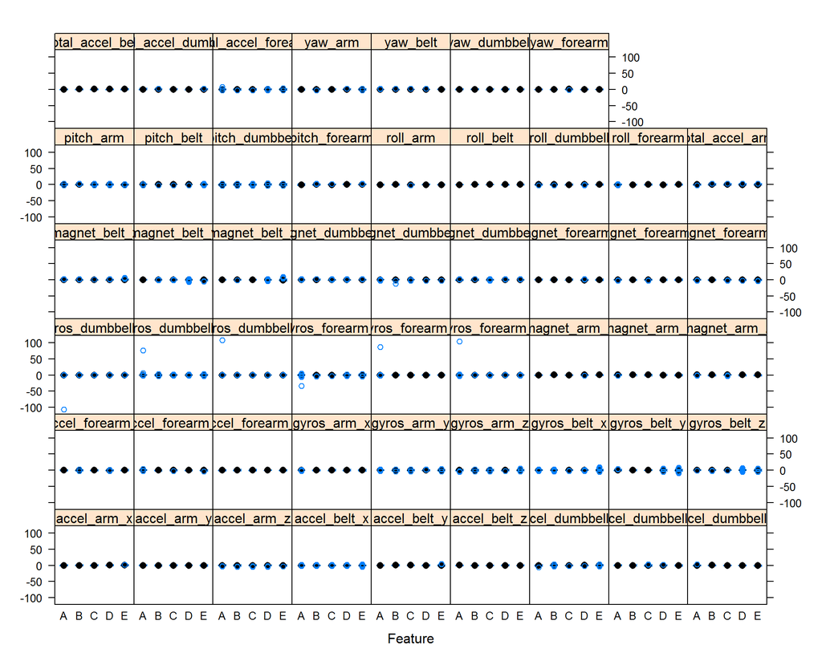

```r
featurePlot(x=trainingP[ , -1], y=trainingP[ , 1], plot="box", auto.key = list(columns = 2))
```

At this moment, further standadization is not made and all variables will be used for model consturction.

# Algorithm Selection

```r
models = c("lda", "gbm", "mda", "rpart", "rf", "treebag", "nb", "LogitBoost")
for (model in models) {
  ### Training the model
  filename <- paste("cache/fit-", model, ".rds", sep="")
  if (file.exists(filename))
  {
    fit <- readRDS(filename)
  }
  else
  {
    fit <- train(classe ~ ., data=trainingP, method=model)
    saveRDS(fit, file=filename)
  }
  ### Predict for cross validation data
  predictValidatoin <- predict(fit, newdata=validationP)
  overall <- confusionMatrix(predictValidatoin, validationP$classe)$overall
  print(sprintf("Model %s: accuracy: %.4f  95%% CI: %.4f - %.4f", model, overall[1], overall[3], overall[4]))
  ### Cleanup to avoid out of memory
  rm(fit, predictValidation)
}
```

```
## [1] "Model lda: accuracy: 0.7030  95% CI: 0.6885 - 0.7173"
## [1] "Model gbm: accuracy: 0.9597  95% CI: 0.9531 - 0.9657"
## [1] "Model mda: accuracy: 0.7609  95% CI: 0.7472 - 0.7742"
## [1] "Model rpart: accuracy: 0.4989  95% CI: 0.4831 - 0.5146"
## [1] "Model rf: accuracy: 0.9916  95% CI: 0.9882 - 0.9942"
## [1] "Model treebag: accuracy: 0.9827  95% CI: 0.9781 - 0.9865"
## [1] "Model nb: accuracy: 0.7387  95% CI: 0.7247 - 0.7524"
## [1] "Model LogitBoost: accuracy: 0.9074  95% CI: 0.8972 - 0.9169"
```

As Random Forest achieved the highest accuracy, it is chosen for the final model.

# Model optimization

Random Forest algorithm with caret package has one tuing parameter called mtrf, which is the number of randomly selected predictors. Here, mtry is set from 1 to 30 and training - cross validation process is conducted as same as prior section.

‘result’ data frame stores the accuracy of all iterations both against training data and cross validation data. Construction of this data frame needed some complicated code, but it is implementation detail and can be ignored for the purpose of understanding the model construction.

```r
### Initialize result DF
result<-data.frame(c(1,1), c(1,1), c("training", "validation"))
for (mtry in seq(1, 30, 1))
{
  ### Training the model
  filename <- paste("cache/fit-rf-mtry-", mtry, ".rds", sep="")
  if (file.exists(filename))
  {
    fit <- readRDS(filename)
  }
  else
  {
    fit <- train(classe ~ ., data=trainingP, method="rf", tuneGrid = data.frame(.mtry = mtry))
    saveRDS(fit, file=filename)
  }
  ### Predict for training data
  predictTraining <- predict(fit, newdata=trainingP)
  result <- rbind(result, c(mtry, confusionMatrix(predictTraining, trainingP$classe)$overall[1], "training"))
  ### Predict for cross validation data
  predictionValidatoin <- predict(fit, newdata=validationP)
  result <- rbind(result, c(mtry, confusionMatrix(predictionValidatoin, validationP$classe)$overall[1], "validation"))
}
### Sanitize result DF
result<-result[-c(1,2), ]
colnames(result) = c("mtry", "accuracy", "type")
result$mtry<-as.numeric(result$mtry)
result$accuracy<-as.numeric(result$accuracy)
```

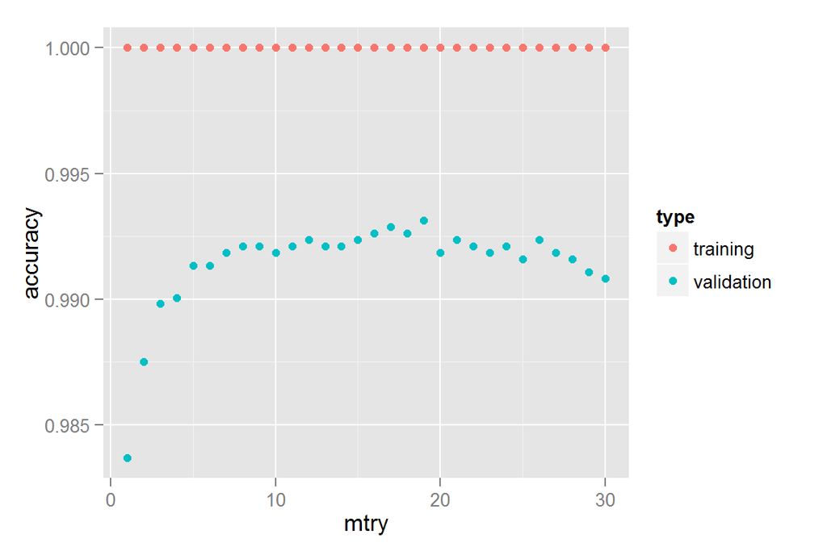

```r
print(qplot(mtry, accuracy, data=result, color=type, geom="point"))
```

# Analysis of training curve

Training is redone here with different numbers of training data.

```r
### Initialize result DF
result<-data.frame(c(1,1), c(1,1), c("training", "validation"))
for (sampleCount in seq(1000, nrow(trainingP), 500))
{
  ### Training the model with subsampled training data.
  filename <- paste("cache/fit-rf-samplecount-", sampleCount, ".rds", sep="")
  set.seed(4911)
  trainingSampledP <- trainingP[sample(1:nrow(trainingP), sampleCount, replace=FALSE), ]
  if (file.exists(filename))
  {
    fit <- readRDS(filename)
  }
  else
  {
    fit <- train(classe ~ ., data=trainingSampledP, method="rf", tuneGrid = data.frame(.mtry = 10))
    saveRDS(fit, file=filename)
  }
  ### Predict for training data
  predictTraining <- predict(fit, newdata=trainingSampledP)
  result <- rbind(result, c(sampleCount, confusionMatrix(predictTraining, trainingSampledP$classe)$overall[1], "training"))
  ### Predict for cross validation data
  predictionValidatoin <- predict(fit, newdata=validationP)
  result <- rbind(result, c(sampleCount, confusionMatrix(predictionValidatoin, validationP$classe)$overall[1], "validation"))
}
### Sanitize result DF
result<-result[-c(1,2), ]
colnames(result) = c("sampleCount", "accuracy", "type")
result$sampleCount<-as.numeric(result$sampleCount)
result$accuracy<-as.numeric(result$accuracy)
```

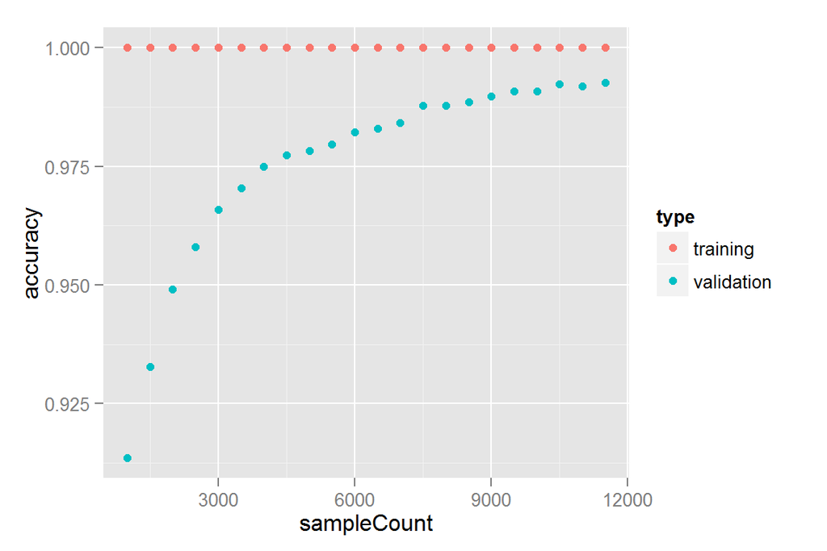

```r
print(qplot(sampleCount, accuracy, data=result, color=type, geom="point"))
```

Accuracy becomes relatively flat after 10 000 samples and it does not meaningfully go down after that. This means a) number of training data is enough under this model and b) the model does not overfit.

# Performance Evaluation

Here is the prediction to the test data with the final prediciton model.

```r
finalFit<-readRDS("cache/fit-rf-mtry-10.rds")
predictTesting <- predict(finalFit, newdata=testingP)
print(confusionMatrix(predictTesting, testingP$classe))
```

```
## Confusion Matrix and Statistics
##
##           Reference
## Prediction    A    B    C    D    E
##          A 1116    9    0    0    0
##          B    0  746    5    0    0
##          C    0    4  679    9    2
##          D    0    0    0  633    2
##          E    0    0    0    1  717
##
## Overall Statistics
##
##                Accuracy : 0.9918
##                  95% CI : (0.9885, 0.9944)
##     No Information Rate : 0.2845
##     P-Value [Acc > NIR] : < 2.2e-16
##
##                   Kappa : 0.9897
##  Mcnemar's Test P-Value : NA
##
## Statistics by Class:
##
##                      Class: A Class: B Class: C Class: D Class: E
## Sensitivity            1.0000   0.9829   0.9927   0.9844   0.9945
## Specificity            0.9968   0.9984   0.9954   0.9994   0.9997
## Pos Pred Value         0.9920   0.9933   0.9784   0.9969   0.9986
## Neg Pred Value         1.0000   0.9959   0.9985   0.9970   0.9988
## Prevalence             0.2845   0.1935   0.1744   0.1639   0.1838
## Detection Rate         0.2845   0.1902   0.1731   0.1614   0.1828
## Detection Prevalence   0.2868   0.1914   0.1769   0.1619   0.1830
## Balanced Accuracy      0.9984   0.9906   0.9940   0.9919   0.9971
```

# Prediction of submission data

Here is the prediction to the cases for automated grading submission. Read the data from CSV and keep only the columns as same as training data has. Then, predict with the final model.

```r
submission <- read.csv(file="pml-testing.csv", header=TRUE, sep=",", quote="\"", na.strings=c("NA",""), as.is = T)
submission <- submission[ , colnames(submission) %in% colnames(training)]
submissionP <- predict(preprocess, submission)
predictSubmission <- predict(finalFit, newdata=submissionP)
print(predictSubmission)
```

```
##  [1] B A B A A E D B A A B C B A E E A B B B
## Levels: A B C D E
```

# Acknowledgment

This dataset is provided by the courtesy of Velloso, E.; Bulling, A.; Gellersen, H.; Ugulino, W.; Fuks, H.. Qualitative Activity Recognition of Weight Lifting Exercises. Proceedings of 4th International Conference in Cooperation with SIGCHI (Augmented Human ’13) . Stuttgart, Germany: ACM SIGCHI, 2013 http://groupware.les.inf.puc-rio.br/work.jsf?p1=11201